# hw 3

korede

9/30/2021

https://github.com/Uloederok/repo

Time of day has an effect on flight delays, so choosing the right time to fly is very important. In 2013, when flying out of New york, to avoid delays as much as possible it is recommended you pick a time early in the morning between 4:30 am and 6 am since it is at those times arrival delays are avoided the mosts.

Delays are however affected by multiple factors, such as airline, month, and airport. Below I will present summaries and figures that better explain this.

17. What time of day should you fly if you want to avoid delays as much as possible?
18. it is recommended you pick a time early in the morning between 4:30 am and 6 am

```r
(time_2fly <- flights %>% group_by(dep_time) %>%
  summarize(delay = mean(arr_delay, na.rm = T)) %>% arrange(delay))
```

```
## # A tibble: 1,319 x 2
##    dep_time delay
##       <int> <dbl>
##  1      447 -31
##  2      449 -20.7
##  3      445 -20
##  4      508 -19.5
##  5      510 -19.2
##  6      523 -18.2
##  7      521 -17.1
##  8      446 -17
##  9      506 -16
## 10      504 -15.3
## # ... with 1,309 more rows
```

17. Does this choice depend on airline?
18. Yes, with the airline that uses the carrier code “VX” as an airline that avoids delays better than others

```r
fly <- flights %>%   group_by(month,dep_time, origin, dest, carrier) %>%
  summarize(delay = mean(arr_delay, na.rm = T)) %>% arrange(delay)


flights %>%   group_by(month,dep_time, origin, dest, carrier) %>%
  summarize(delay = mean(arr_delay, na.rm = T)) %>% arrange(delay, carrier)
```

```
## # A tibble: 221,333 x 6
## # Groups:   month, dep_time, origin, dest [210,451]
##    month dep_time origin dest  carrier delay
##    <int>    <int> <chr>  <chr> <chr>   <dbl>
##  1     5     1715 EWR    SFO   VX        -86
##  2     5      719 JFK    SFO   VX        -79
##  3     5     1826 JFK    SEA   AA        -75
##  4     5     1801 JFK    LGB   B6        -70
##  5     2     1335 EWR    HNL   UA        -70
##  6     5      616 JFK    PHX   US        -70
##  7     5     1914 EWR    LAS   UA        -69
##  8     2     1022 JFK    SFO   VX        -69
##  9     5     1846 JFK    MCI   9E        -68
## 10     9     1550 LGA    DFW   AA        -68
## # ... with 221,323 more rows
```

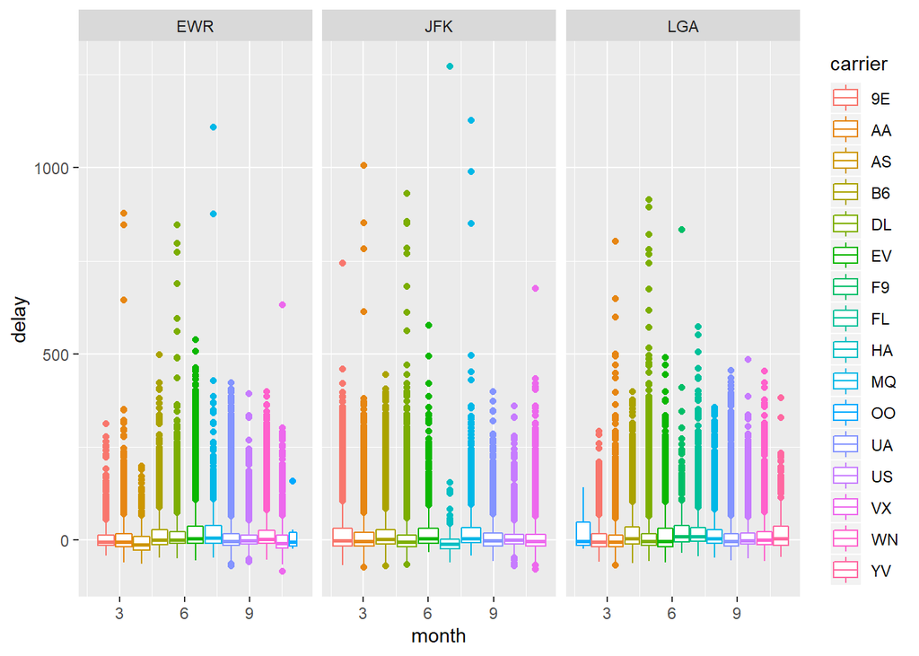

```r
ggplot(fly, mapping = aes(month, delay)) + geom_boxplot(aes(colour = carrier)) + facet_wrap(origin~.)
```

Does this choice depend on airport?

If you want to avoid delays as much as possible, it is best to not fly into JFK airport out of the 3 New york airports in question, since the JFK airport has the highest number of arrival delays

```r
fly <- flights %>%   group_by(month,dep_time, origin, dest, carrier) %>%
  summarize(delay = mean(arr_delay, na.rm = T)) %>% arrange(delay)


flights %>%   group_by(month,dep_time, origin, dest, carrier) %>%
  summarize(delay = mean(arr_delay, na.rm = T)) %>% arrange(desc(delay, origin))
```

```
## # A tibble: 221,333 x 6
## # Groups:   month, dep_time, origin, dest [210,451]
##    month dep_time origin dest  carrier delay
##    <int>    <int> <chr>  <chr> <chr>   <dbl>
##  1     1      641 JFK    HNL   HA       1272
##  2     6     1432 JFK    CMH   MQ       1127
##  3     1     1121 EWR    ORD   MQ       1109
##  4     9     1139 JFK    SFO   AA       1007
##  5     7      845 JFK    CVG   MQ        989
##  6     4     1100 JFK    TPA   DL        931
##  7     3     2321 LGA    MSP   DL        915
##  8     7     2257 LGA    ATL   DL        895
##  9    12      756 EWR    MIA   AA        878
## 10     5     1133 EWR    ORD   MQ        875
## # ... with 221,323 more rows
```

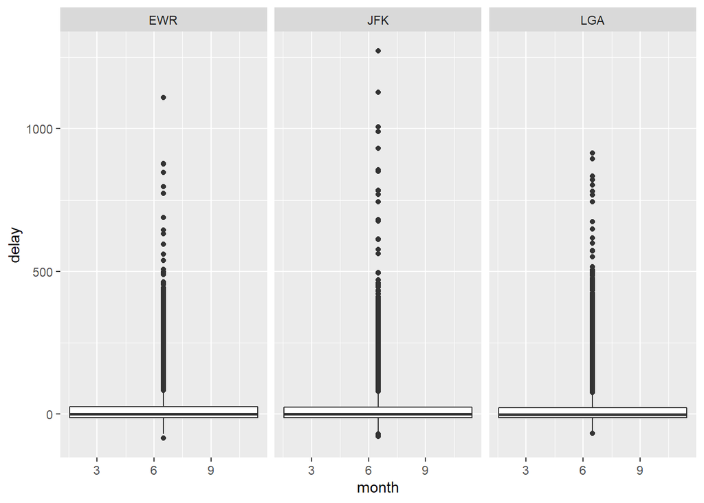

```r
ggplot(fly, mapping = aes(month, delay)) + geom_boxplot() + facet_wrap(origin~.)
```

Does this choice depend on the month?

If you want to avoid delays as much as possible, it is best to fly during the May

```r
fly <- flights %>%   group_by(month,dep_time, origin, dest, carrier) %>%
  summarize(delay = mean(arr_delay, na.rm = T)) %>% arrange(delay)


flights %>%   group_by(month,dep_time, origin, dest, carrier) %>%
  summarize(delay = mean(arr_delay, na.rm = T)) %>% arrange(delay, month)
```

```
## # A tibble: 221,333 x 6
## # Groups:   month, dep_time, origin, dest [210,451]
##    month dep_time origin dest  carrier delay
##    <int>    <int> <chr>  <chr> <chr>   <dbl>
##  1     5     1715 EWR    SFO   VX        -86
##  2     5      719 JFK    SFO   VX        -79
##  3     5     1826 JFK    SEA   AA        -75
##  4     2     1335 EWR    HNL   UA        -70
##  5     5      616 JFK    PHX   US        -70
##  6     5     1801 JFK    LGB   B6        -70
##  7     2     1022 JFK    SFO   VX        -69
##  8     5     1914 EWR    LAS   UA        -69
##  9     5     1536 EWR    SAN   UA        -68
## 10     5     1846 JFK    MCI   9E        -68
## # ... with 221,323 more rows
```

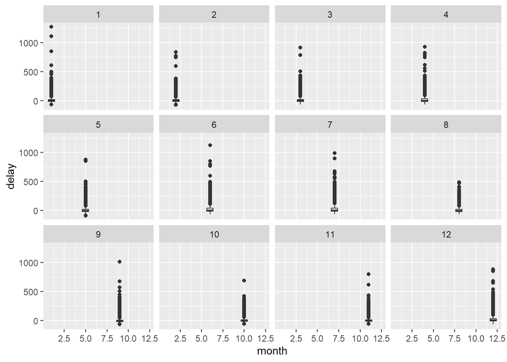

```r
ggplot(fly, mapping = aes(month, delay)) + geom_boxplot() + facet_wrap(month~.)
```